# 02 Exploratory Analyses

Leeann Comfort

May 1, 2018

## Overview

**Purpose**  
To calculate and compare intraclass coefficients for LIWC measures To visualize the LIWC2015 results, comparing the language use by:

- high- and low-performing organizations
- high- and low-performing sites
- role (doctor, nurse, medical assistant) of interviewee
- interviewer/interviewee

**Output**  
8 .png files, 2 for each comparison group (summary measures, non-summary measures):

- high- and low-performing organizations
- high- and low-performing sites
- role (doctor, nurse, medical assistant) of interviewee
- interviewer/interviewee

2 .png file of plotted ICC scores for all variables:

- Within-individual ICCs
- Within-site ICCs

**Notes**  
* Output produces large files (20“x10”) for scrolling; do not attempt to print * Planned updates: to update the visualizations by group into a function  
* Summary measures are the 4 measures new to LIWC2015 (Analytic, Clout, Authentic, and Tone); non-summary measures are all the other LIWC measures

## Setup

```r
knitr::opts_knit$set(root.dir = "/Users/comfort/Box Sync/ps239T-final-project")
# dir <- .libPaths()
# install.packages("ggplot2", repos = "https://cran.cnr.berkeley.edu/", destdir = dir)
# install.packages("purrr", repos = "https://cran.cnr.berkeley.edu/", destdir = dir)
# install.packages("dplyr", repos = "https://cran.cnr.berkeley.edu/", destdir = dir)
# install.packages("reshape", repos = "https://cran.cnr.berkeley.edu/", destdir = dir)
# install.packages("ICC", repos = "https://cran.cnr.berkeley.edu/", destdir = dir)
# install.packages("tidyr", repos = "https://cran.cnr.berkeley.edu/", destdir = dir)

library(ggplot2)
library(purrr)
library(dplyr)
library(reshape)
library(ICC)
library(tidyr)
```

### Create long data frames

```r
df <- read.csv("./Data/liwc_one_2018-05-02.csv")  #

# Transform workgroup, site, aco, perform into factor, shorten name
df$speakid <- as.factor(df$speakanon)
df$role <- as.factor(df$workgroup_collapsed)
df$site <- as.factor(df$site)
df$aco <- as.factor(df$aco)
df$perform <- as.factor(df$perform)



# Transform speakanon IDs to characters so that all the interviewees could be recoded as "respondent"
df$speakanon <- as.character(df$speakanon)
df$speakanon[df$speakanon != "interviewer"] = "respondent"


# Drop observations where site == 0
# (2 management interviews, only in the high performing sites so not comparable to low performing sites)
df <- df[!(df$site==0),]

# Some clean up, dropping unneeded varaibles, rearranging order of variables
df <- df[ , -which(names(df) %in% c("workgroup_collapsed", "X", "WPS", "WC"))]
df <- df %>% select(aco, perform, site, role, speakanon, speakid, everything())

# Note: subsetting the variables directly in ggplot seems to run pretty slowly, so this creates standalone dfs
dfl <- melt(df, id=c("aco", "perform", "site", "role", "speakanon", "speakid"))

# Long dataset; Identifiers & Summary Variables Only
dfl_sum <- dfl[ which(dfl$variable=='Analytic' |
                      dfl$variable=='Clout' |
                      dfl$variable=='Authentic' |
                      dfl$variable=='Tone' ), ]

# Long dataset; Identifiers & Non-Summary Variables Only
dfl_nsm <- dfl[ which(dfl$variable!='Analytic' &
                      dfl$variable!='Clout' &
                      dfl$variable!='Authentic' &
                      dfl$variable!='Tone' ), ]

# Long dataset, respondents only
dflr <- dfl[ which(dfl$speakanon=='respondent'), ]

# Long dataset, respondents only; Identifiers & Summary Variables Only
dflr_sum <- dflr[ which(dflr$variable=='Analytic' |
                        dflr$variable=='Clout' |
                        dflr$variable=='Authentic' |
                        dflr$variable=='Tone' ), ]

# Long dataset, respondents only; Identifiers & Non-Summary Variables Only
dflr_nsm <- dflr[ which(dflr$variable!='Analytic' &
                        dflr$variable!='Clout' &
                        dflr$variable!='Authentic' &
                        dflr$variable!='Tone' ), ]
```

## Comparisons

Create datasets in long format (so that variables can be used as facets).  
Summary variables are presented separately from the other variables because they tend to distort the shared graph axes

### By High & Low Performing Organizations

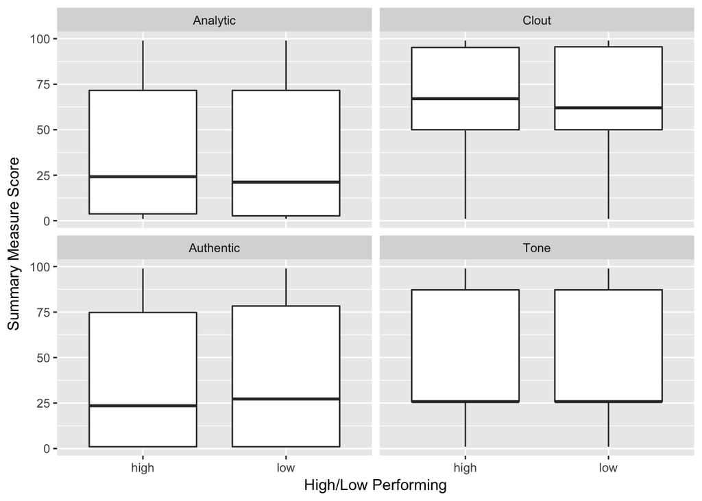

```r
# Generate graphs for Summary Variables
  ggplot(dflr_sum, aes(x=perform, y=value)) +
      geom_boxplot() +
      facet_wrap(~variable) +
      ylab("Summary Measure Score") +
      xlab("High/Low Performing")
```

```r
  ggsave(filename = "HL_SummaryVars.png", device='png', path="./Results/")
```

```r
# Generate graphs for Non-Summary Variables
  #These are so big that it only makes sense to scroll through the actual files
invisible(
  ggplot(dflr_nsm, aes(x=perform, y=value)) +
    geom_boxplot() +
    facet_wrap(~variable) +
    ylab("Proportion of Words") +
    xlab("High/Low Performing")
)
  ggsave(filename = "HL_NonSummaryVars.png", width = 10, height = 20, dpi = 150, units = "in", device='png', path="./Results/")
```

### By Sites

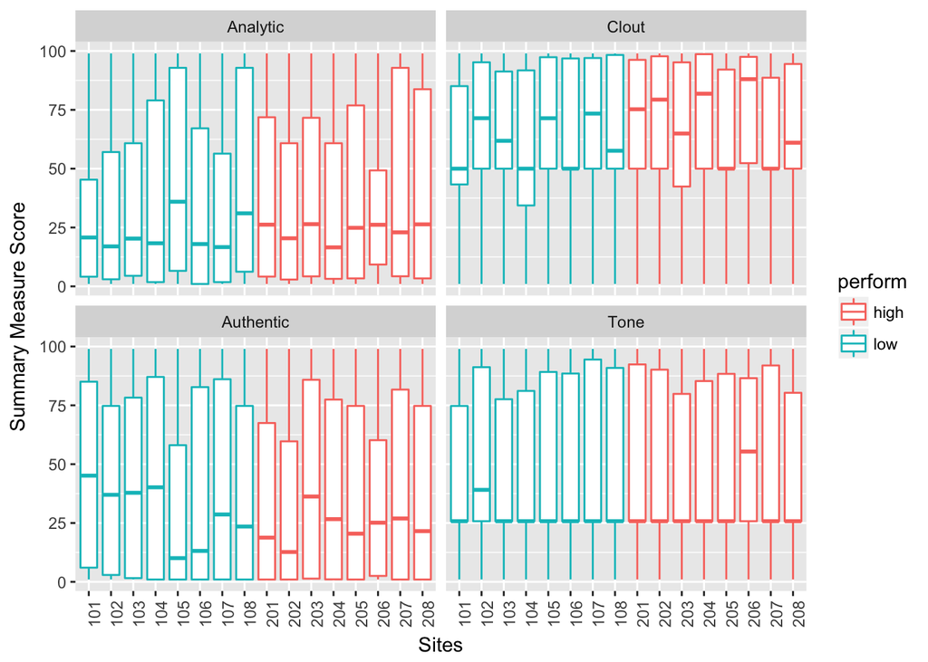

```r
  ggplot(dflr_sum, aes(x=site, y=value, color=perform)) +
      geom_boxplot() +
      facet_wrap(~variable) +
      ylab("Summary Measure Score") +
      xlab("Sites") +
      theme(axis.text.x=element_text(angle=90, hjust=1))
```

```r
  ggsave(filename = "Site_Summary.png", width = 10, height = 20, dpi = 150, units = "in", device='png', path="./Results/")


# Generate graphs for Non-Summary Variables
  #These are so big that it only makes sense to scroll through the actual files
invisible(
  ggplot(dflr_nsm, aes(x=site, y=value, color=perform)) +
    geom_boxplot() +
    facet_wrap(~variable) +
    ylab("Proportion of Words") +
    xlab("Sites") +
    theme(axis.text.x=element_text(angle=90, hjust=1))
)

  ggsave(filename = "Site_NonSummary.png", width = 20, height = 40, dpi = 150, units = "in", device='png', path="./Results/")
```

### By Roles

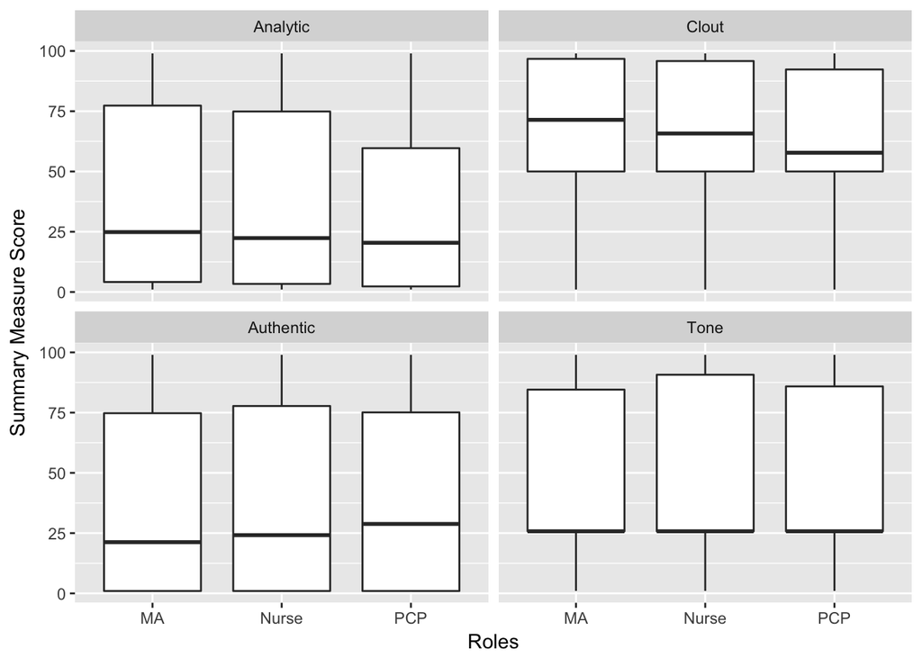

```r
# Generate graphs for Summary Variables
  ggplot(dflr_sum, aes(x=role, y=value)) +
      geom_boxplot() +
      facet_wrap(~variable) +
      ylab("Summary Measure Score") +
    xlab("Roles")
```

```r
  ggsave(filename = "Role_Summary.png", width = 10, height = 20, dpi = 150, units = "in", device='png', path="./Results/")


# Generate graphs for Non-Summary Variables
  #These are so big that it only makes sense to scroll through the actual files
invisible(
  ggplot(dflr_nsm, aes(x=role, y=value)) +
    geom_boxplot() +
    facet_wrap(~variable) +
    ylab("Proportion of Words") +
    xlab("Roles")
)
 ggsave(filename = "Role_NonSummary.png", width = 20, height = 40, dpi = 150, units = "in", device='png', path="./Results/")
```

### Compare Interviewer v. Interviewee Data

*These analyses were used to determine that the interviewer language was somewhat different from the interviewee data (for the summary variables), and so should be removed from statistical analyses (to remove noise)*

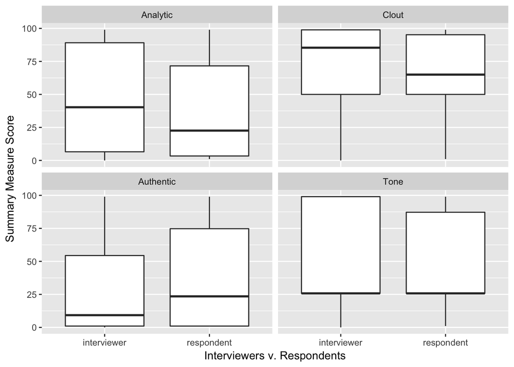

```r
# Generate graphs for Summary Variables
  ggplot(dfl_sum, aes(x=speakanon, y=value)) +
      geom_boxplot() +
      facet_wrap(~variable) +
      ylab("Summary Measure Score") +
      xlab("Interviewers v. Respondents")
```

```r
  ggsave(filename = "IR_Summary.png", width = 10, height = 20, dpi = 150, units = "in", device='png', path="./Results/")


# Generate graphs for Non-Summary Variables
  #These are so big that it only makes sense to scroll through the actual files
invisible(
  ggplot(dfl_nsm, aes(x=speakanon, y=value)) +
    geom_boxplot() +
    facet_wrap(~variable) +
    ylab("Proportion of Words") +
    xlab("Interviewers v. Respondents") +
    theme(axis.text.x=element_text(angle=45, hjust=1))

)
  ggsave(filename = "IR_NonSummary.png", width = 10, height = 20, dpi = 150, units = "in", device='png', path="./Results/")
```

## Assessing Within-Person ICCs of LIWC Measures

Estimates the ICC and confidence intervals using the variance components from a one-way ANOVA

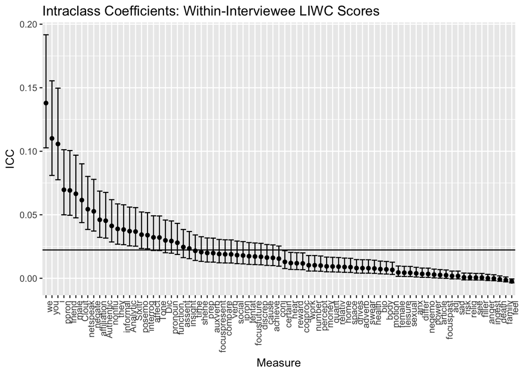

```r
# Create a list of the "dependent variables" by removing the interviewee/site data:
DV <- names(df)[! names(df) %in%
                  c("aco", "perform", "site", "role", "speakanon", "WPS", "WC", "X", "speakid")]

# Calculates person-level ICC scores for each of the Dependent variables (creates a list of lists)
temp <-  lapply(DV, function(x) ICCest(speakid, x, data = df, alpha = 0.05, CI.type = c("THD", "Smith")))

# Turns the list of lists into a data frame
ICC_results <-  map_df(temp, ~bind_rows(.), .id="EXP")  %>%
                cbind.data.frame(DV) %>%
                arrange(ICC)


# Plot all the ICC values
ggplot(ICC_results, aes(x = reorder(DV, -ICC), y=ICC)) +
  geom_point() +
  geom_abline(intercept = .0222872, slope = 0) +
  theme(axis.text.x=element_text(angle=90,hjust=1)) +
  geom_errorbar(aes(ymin = LowerCI, ymax = UpperCI)) +
  ggtitle("Intraclass Coefficients: Within-Interviewee LIWC Scores") +
  xlab("Measure")
```

```r
ggsave(filename = "ICC_ind.png", width = 10, height = 20, dpi = 150, units = "in", device='png', path="./Results/")
```

## Assessing Within-Site ICCs of LIWC Measures

Estimates the ICC and confidence intervals using the variance components from a one-way ANOVA

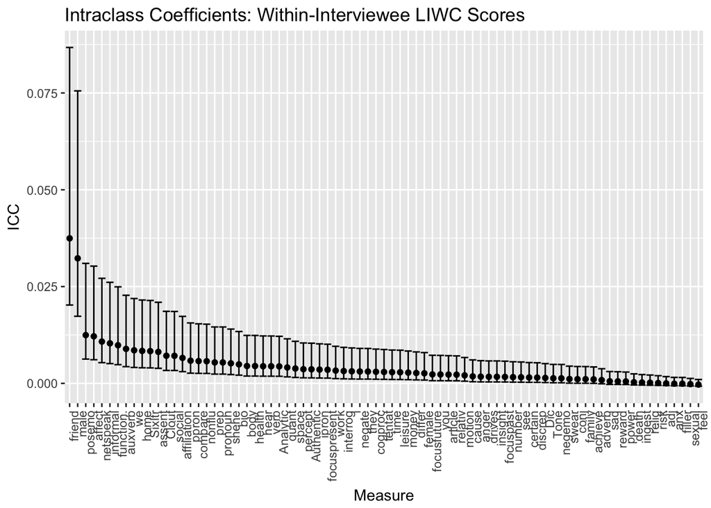

```r
# Calculates site-level ICC scores for each of the Dependent variables (creates a list of lists)
temp <-  lapply(DV, function(x) ICCest(site, x, data = df, alpha = 0.05, CI.type = c("THD", "Smith")))

# Turns the list of lists into a data frame
ICC_results_site <-  map_df(temp, ~bind_rows(.), .id="EXP")  %>%
                cbind.data.frame(DV) %>%
                arrange(ICC)


# Plot all the ICC values
ggplot(ICC_results_site, aes(x = reorder(DV, -ICC), y=ICC)) +
  geom_point() +
  theme(axis.text.x=element_text(angle=90,hjust=1)) +
  geom_errorbar(aes(ymin = LowerCI, ymax = UpperCI)) +
  ggtitle("Intraclass Coefficients: Within-Interviewee LIWC Scores") +
  xlab("Measure")
```

```r
ggsave(filename = "ICC_site.png", width = 10, height = 20, dpi = 150, units = "in", device='png', path="./Results/")
```